# Características epidemiológicas y clínicas de los Trastornos del Neurodesarrollo en población infantil en el periodo 2016 al 2023

Cuaderno de análisis de datos

Author

Affiliation

Gloria Andrea Rico Velasco, MsC

Universidad San Buenaventura

Published

Tuesday, December 3, 2024

Keywords

Neurodesarrollo, Políticas públicas de salud mental, Transtornos del neurodesarrollo

Esta investigación tiene como objetivo describir las características epidemiológicas de los trastornos del neurodesarrollo en población infantil en Colombia.

# 1 Instalacion de paquetes

A continuación se instalan los paquetes necesarios para desarrollar el modelo estadístico.

```r
if (!require("brms")) install.packages("brms")
if (!require("broom.mixed")) install.packages("broom.mixed")
if (!require("dplyr")) install.packages("dplyr")
if (!require("ggalluvial")) install.packages("ggalluvial")
if (!require("ggplot2")) install.packages("ggplot2")
if (!require("glmmTMB")) install.packages("glmmTMB")
if (!require("here")) install.packages("here")
if (!require("lme4")) install.packages("lme4")
if (!require("MASS")) install.packages("MASS")
if (!require("MetBrewer")) install.packages("MetBrewer")
if (!require("performance")) install.packages("performance")
if (!require("readxl")) install.packages("readxl")
if (!require("tidybayes")) install.packages("tidybayes")
```

# 2 Funciones para visualizacion de datos

```r
Plot_theme <- theme_classic() +
  theme(
      plot.title = element_text(size=18, hjust = 0.5, face="bold"),
      plot.subtitle = element_text(size = 10, color = "black"),
      plot.caption = element_text(size = 12, color = "black"),
      axis.line = element_line(colour = "black", linewidth = 1.5, linetype = "solid"),
      axis.ticks.length=unit(7,"pt"),

      axis.title.x = element_text(colour = "black", size = 16),
      axis.text.x = element_text(colour = "black", size = 16, angle = 0, hjust = 0.5),
      axis.ticks.x = element_line(colour = "black", linewidth = 1),

      axis.title.y = element_text(colour = "black", size = 16),
      axis.text.y = element_text(colour = "black", size = 16),
      axis.ticks.y = element_line(colour = "black", linewidth = 1),

      legend.position="right",
      legend.direction="vertical",
      legend.title = element_text(colour="black", face="bold", size=12),
      legend.text = element_text(colour="black", size=10),

      plot.margin = margin(t = 10,  # Top margin
                             r = 2,  # Right margin
                             b = 10,  # Bottom margin
                             l = 10) # Left margin
      )
```

# 3 Lectura y limpieza de dataset

Se cargan los datos contedidos en la tabla “Data/Ministerio_Datos_Limpios.xlsx”. Se eliminan las casillas con valores faltantes “NA”

```r
##leer archivo excel

Datos_Limpios_Analisis_Ministerio <- read_excel(here("Data/Ministerio_Datos_Limpios.xlsx"))

# Eliminar filas con valores NA en cualquier columna
Datos_Limpios_Analisis_Ministerio <- na.omit(Datos_Limpios_Analisis_Ministerio)

str (Datos_Limpios_Analisis_Ministerio)
```

```
tibble [772,313 × 8] (S3: tbl_df/tbl/data.frame)
 $ Año         : num [1:772313] 2016 2016 2016 2016 2016 ...
 $ Año_cod     : num [1:772313] 0 0 0 0 0 0 0 0 0 0 ...
 $ Departamento: chr [1:772313] "Antioquia" "Antioquia" "Antioquia" "Antioquia" ...
 $ Municipio   : chr [1:772313] "Medellín" "Medellín" "Medellín" "Medellín" ...
 $ Diagnostico : chr [1:772313] "F700" "F700" "F700" "F700" ...
 $ Edades      : chr [1:772313] "De 02 años" "De 04 años" "De 04 años" "De 06 años" ...
 $ Sexo        : chr [1:772313] "MASCULINO" "FEMENINO" "MASCULINO" "FEMENINO" ...
 $ cantidad_p  : num [1:772313] 1 2 1 1 1 3 8 5 6 8 ...
 - attr(*, "na.action")= 'omit' Named int [1:14368] 13547 13548 13549 13550 13551 13552 13553 13554 13555 13556 ...
  ..- attr(*, "names")= chr [1:14368] "13547" "13548" "13549" "13550" ...
```

## 3.1 Procesamiento de los datos

A continuación procesamos la columa de “Edades” para seleccionar solamente los valores numéricos y establecemos la columna de sexo como un factor:

```r
Datos_Limpios_Analisis_Ministerio <- Datos_Limpios_Analisis_Ministerio %>%
  mutate(
    Edades = as.numeric(gsub("De | años", "", Edades)),
    Sexo = factor(Sexo, levels = c("FEMENINO", "MASCULINO")),
    Diagnostico = factor(Diagnostico))


str(Datos_Limpios_Analisis_Ministerio)
```

```
tibble [772,313 × 8] (S3: tbl_df/tbl/data.frame)
 $ Año         : num [1:772313] 2016 2016 2016 2016 2016 ...
 $ Año_cod     : num [1:772313] 0 0 0 0 0 0 0 0 0 0 ...
 $ Departamento: chr [1:772313] "Antioquia" "Antioquia" "Antioquia" "Antioquia" ...
 $ Municipio   : chr [1:772313] "Medellín" "Medellín" "Medellín" "Medellín" ...
 $ Diagnostico : Factor w/ 50 levels "F700","F701",..: 1 1 1 1 1 1 1 1 1 1 ...
 $ Edades      : num [1:772313] 2 4 4 6 6 7 7 8 8 9 ...
 $ Sexo        : Factor w/ 2 levels "FEMENINO","MASCULINO": 2 1 2 1 2 1 2 1 2 1 ...
 $ cantidad_p  : num [1:772313] 1 2 1 1 1 3 8 5 6 8 ...
 - attr(*, "na.action")= 'omit' Named int [1:14368] 13547 13548 13549 13550 13551 13552 13553 13554 13555 13556 ...
  ..- attr(*, "names")= chr [1:14368] "13547" "13548" "13549" "13550" ...
```

# 4 Exploración visual de los datos

Para este ejercicio analizaremos tres diagnósticos. Los datos utilizados, denominados Datos_top_3, corresponden a los diagnósticos más prevalentes de trastornos del neurodesarrollo. En primer lugar, filtramos los datos, obteniendo los tres diagósticos más comunes y asegurandonos de que la tabla contenga solamente filas con “FEMENINO” Y “MASCULINO.

```r
top_3_diagnosticos <- Datos_Limpios_Analisis_Ministerio %>%
  group_by(Diagnostico) %>%
  summarise(total_diagnosticos = sum(cantidad_p, na.rm = TRUE)) %>%
  arrange(desc(total_diagnosticos)) %>%
  slice_head(n = 3) %>%
  pull(Diagnostico)  # Extraer los 3 diagnósticos más prevalentes

Datos_top_3 <- Datos_Limpios_Analisis_Ministerio %>%
  filter(Diagnostico %in% top_3_diagnosticos)
Datos_top_3 <- filter(Datos_top_3,Sexo=='FEMENINO'| Sexo=='MASCULINO')
Datos_top_3$Diagnostico <- factor(Datos_top_3$Diagnostico, levels = c("F808", "F809", "F900"))
```

Ahora, visualizamos la distribución:

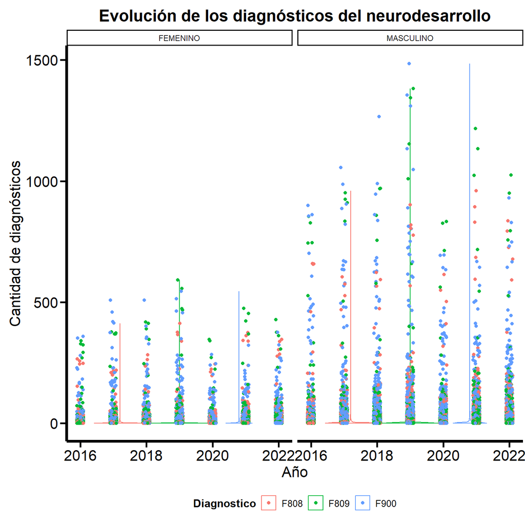

Figure 1: Evolución del número de diagnósticos por sexo

```r
Neurodesarrollo_Expl <- ggplot(
Datos_top_3 ,
  aes(
    x = Año,
    y = cantidad_p,
    color = Diagnostico
  )
) +
  geom_violin()+
  geom_point(position = position_jitter(width = 0.1)) +
  labs(y = "Cantidad de diagnósticos")+
  ggtitle("Evolución de los diagnósticos del neurodesarrollo")+
  Plot_theme +
  theme(legend.position = "bottom",
        legend.direction = "horizontal") +
  facet_wrap(~ Sexo)


ggsave(Neurodesarrollo_Expl,
       filename = here("Plots/Neurodesarrollo_Expl.png"),
       width    = 16,
       height   = 12,
       units    = "cm")

Neurodesarrollo_Expl
```

Figure 1 revela que los diagnósticos pueden alcanzar más de 1000 y presentar una dispersion sustancial que no permite observar su distribución. Esto indica que aunque exiten cantidades elevadas de diagnósticos, la mayoría de ellos se encuentran centrados en números bajos (ceranos al cero). Debido a la naturaleza y dispersion de los datos, es oportuno modelarlos utilizando una distribución negativa binomial.

# 5 Modelo de regresion lineal

El objetivo de este análisis es evaluar el efecto de las variables Año_cod (años codificados) y Diagnóstico (categoría de diagnóstico) sobre la variable dependiente cantidad_p, que representa la cantidad de casos reportados. Ajustamos el siguiente modelo:

$$Casos = \beta_0 + \beta_1 \times Año + \beta_2 \times Diagnóstico + \beta_3 \times (Año \times Diagnóstico) + \epsilon_i$$

## 5.1 Ajuste del modelo

Utilizamos una distribución binomial negativa (`negbinomial`) para modelar los datos, considerando la interacción entre el diagnóstico y el año.

```r
Neurodesarrollo_Mdl1 <- bf(cantidad_p ~ Año_cod * Diagnostico)

get_prior(Neurodesarrollo_Mdl1, Datos_top_3, family = negbinomial())
```

```
                prior     class                    coef group resp dpar nlpar
               (flat)         b
               (flat)         b                 Año_cod
               (flat)         b Año_cod:DiagnosticoF809
               (flat)         b Año_cod:DiagnosticoF900
               (flat)         b         DiagnosticoF809
               (flat)         b         DiagnosticoF900
 student_t(3, 0, 2.5) Intercept
  inv_gamma(0.4, 0.3)     shape
 lb ub       source
            default
       (vectorized)
       (vectorized)
       (vectorized)
       (vectorized)
       (vectorized)
            default
  0         default
```

```r
Neurodesarrollo_Fit1 <-
  brm(
    data = Datos_top_3,
    family = negbinomial,
    formula = Neurodesarrollo_Mdl1,
    chains = 4,
    cores = 4,
    warmup = 2500,
    iter = 5000,
    seed = 8807,
    control = list(adapt_delta = 0.99, max_treedepth = 15),
    file = here("Models/Neurodesarrollo_Fit1.rds"),
    file_refit = "never"
  )
```

A continuación, visualizamos los coefficientes obtenidos:

```r
summary(Neurodesarrollo_Fit1)
```

```
 Family: negbinomial
  Links: mu = log; shape = identity
Formula: cantidad_p ~ Año_cod * Diagnostico
   Data: Datos_top_3 (Number of observations: 161220)
  Draws: 4 chains, each with iter = 5000; warmup = 2500; thin = 1;
         total post-warmup draws = 10000

Regression Coefficients:
                        Estimate Est.Error l-95% CI u-95% CI Rhat Bulk_ESS
Intercept                   1.35      0.01     1.33     1.37 1.00     3875
Año_cod                     0.04      0.00     0.03     0.04 1.00     3725
DiagnosticoF809             0.12      0.02     0.09     0.15 1.00     3934
DiagnosticoF900             0.79      0.02     0.76     0.82 1.00     3783
Año_cod:DiagnosticoF809    -0.02      0.00    -0.03    -0.01 1.00     3757
Año_cod:DiagnosticoF900    -0.08      0.00    -0.09    -0.07 1.00     3634
                        Tail_ESS
Intercept                   5296
Año_cod                     5515
DiagnosticoF809             5497
DiagnosticoF900             5000
Año_cod:DiagnosticoF809     5350
Año_cod:DiagnosticoF900     4702

Further Distributional Parameters:
      Estimate Est.Error l-95% CI u-95% CI Rhat Bulk_ESS Tail_ESS
shape     0.60      0.00     0.59     0.60 1.00     7695     6302

Draws were sampled using sampling(NUTS). For each parameter, Bulk_ESS
and Tail_ESS are effective sample size measures, and Rhat is the potential
scale reduction factor on split chains (at convergence, Rhat = 1).
```

Con el procedimiento anterior utilizamos una distribución binomial negativa para la variable respuesta. Esta distribución es apropiada en casos donde el recuento de unidades presenta sobredispersión, es decir, donde la varianza supera con creces a la media.

La función de enlace para el parámetro de la media ($\mu$) es el enlace logarítmico. Esto implica que $log (\mu)$ = predictor lineal. Para interpretar estos resultados en la escala natural, es necesario exponenciar los coefficientes:

- El intercepto (el valor del diagnóstico F808 en el 2016) es exp(1.35) ≈ 3.86
- El efecto del año es exp(0.04) ≈ 1.04. Esto implica un aumento del 4% por cada año que pasa.
- El diagnóstico F809 hay un incremento de exp(0.12) ≈ 1.13, un aumento del 13% en el 2016. Por otra parte, el aumento para F900 aumenta en exp(0.79) ≈ 2.20, un incremento del 120%.
- Para el diagnóstico F809, el cambio por año reduce el incremento de diagnósticos en exp(-0,02) ≈0,98. Es decir, una disminución del 2% por unidad. Por el contrario, esta disminución es de exp(-0,08)≈0,92 (8% por unidad) para el diagnóstico F900.
- Finalmente, el coefficiente para shape es 0,60, lo que nos sugiere una sobredispersión moderada en los conteos.

Ahora visualizamos los resultados utilizando la función `conditional_effects`:

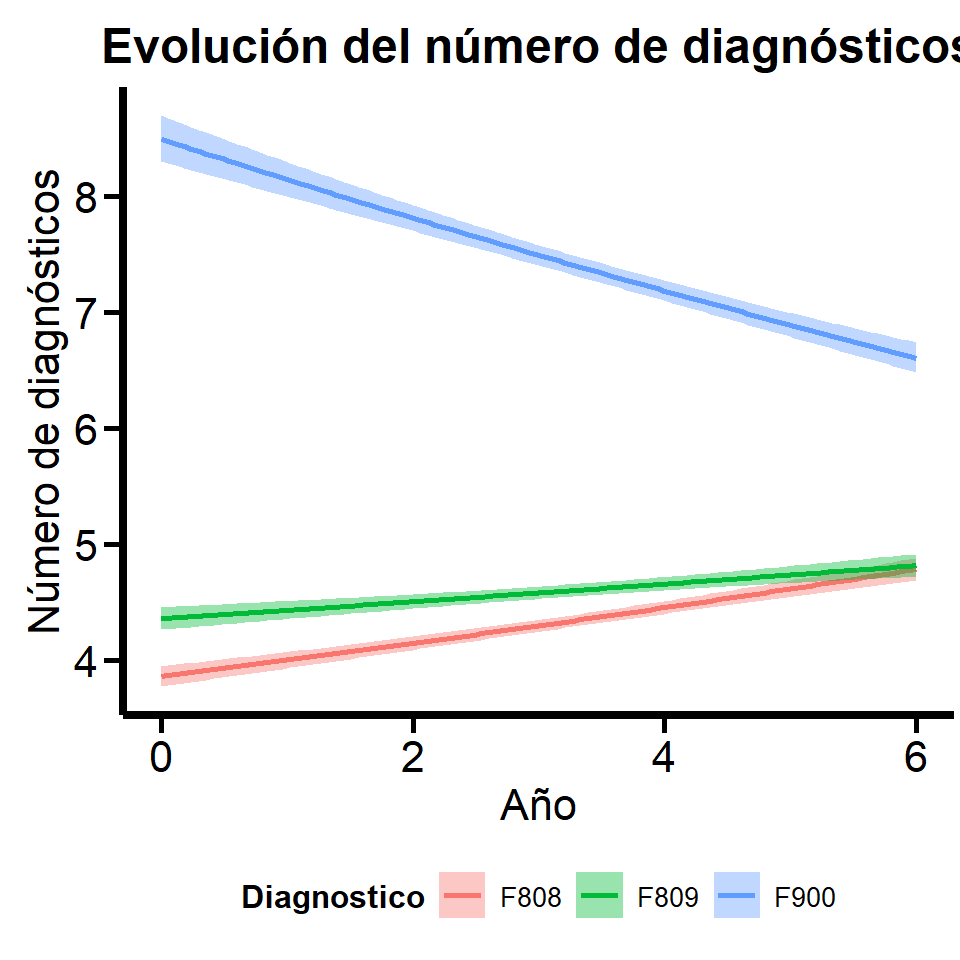

Figure 2: Evolución del número de diagnósticos por año

```r
Neurodesarrollo_CE <- conditional_effects(Neurodesarrollo_Fit1)

Neurodesarrollo_CE_Fig <- plot(Neurodesarrollo_CE , plot = FALSE)[[3]]

Neurodesarrollo_CE_Fig <- Neurodesarrollo_CE_Fig +
  labs(title = "Evolución del número de diagnósticos",
       y = "Número de diagnósticos",
       x = "Año") +
  Plot_theme +
  theme(legend.position = "bottom",
        legend.direction = "horizontal")

ggsave (Neurodesarrollo_CE_Fig,
        file = here("Plots/Neurodesarrollo_Fit1.jpg"),
        width = 15,
        height = 12,
        units = "cm")

Neurodesarrollo_CE_Fig
```

```r
clrs <- MetBrewer::met.brewer("Lakota", 6)

Neurodesarrollo_CE_Fig2 <- Datos_top_3 %>%
  add_epred_draws(Neurodesarrollo_Fit1, ndraws = 50, allow_new_levels = TRUE) %>%
  ggplot(aes(x = Año_cod, y = cantidad_p, color = Diagnostico)) +
  geom_point(data = Datos_top_3, size = 1) +
  geom_line(aes(y = .epred, group = paste(Diagnostico, .draw)),
            size = 0.5, alpha = 0.3) +
  scale_color_manual(values = c(clrs[6], clrs[3], clrs[2])) +
  labs(title = "Evolución del número de diagnósticos",
        x = "Año",
       y = "Número de diagnósticos",
       color = "Party") +
  scale_y_continuous(limits = c(0, 10)) +
  Plot_theme +
  theme(legend.position = "bottom",
        legend.direction = "horizontal")

ggsave (Neurodesarrollo_CE_Fig2,
        file = here("Plots/Neurodesarrollo_Fit1_2.jpg"),
        width = 15,
        height = 12,
        units = "cm")
```

Adicionalmente, podemos hacer una validación del modelo utilizando la fuincion `pp_check` de `brms`.

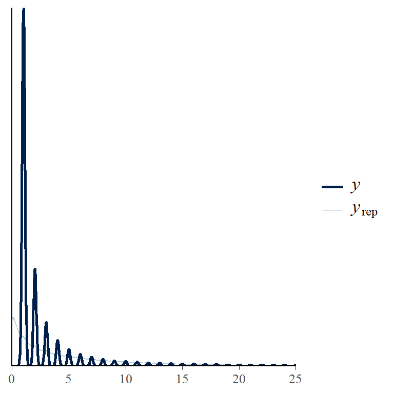

Figure 3: Evaluación del modelo ajustado

```r
pp_check(Neurodesarrollo_Fit1, ndraws = 500) +
  scale_x_continuous(limits=c(0, 25))
```

Figure 3 Nos muestra que nuestras predicciones se desvían sustancialmente de las observaciones. Esto quiere decir que nuestro modelo no es lo suficientemente explicativo para capturar la naturaleza del número de diagnósticos.

# 6 Modelo multinivel

Como complemento, realizamos el ajusted de un modelo multinivel para considerar la dispersión de datos por departamento.

```r
Neurodesarrollo_Fit2 <- glmer(cantidad_p ~ Año_cod * Diagnostico + (1|Departamento),
                              family = "poisson",
                              data = Datos_top_3,
                              control = glmerControl(optimizer = "bobyqa"))
```

Imprimimos los resultados de igual manera que con el modelo anterior:

```r
summary(Neurodesarrollo_Fit2)
```

```
Generalized linear mixed model fit by maximum likelihood (Laplace
  Approximation) [glmerMod]
 Family: poisson  ( log )
Formula: cantidad_p ~ Año_cod * Diagnostico + (1 | Departamento)
   Data: Datos_top_3
Control: glmerControl(optimizer = "bobyqa")

     AIC      BIC   logLik deviance df.resid
 2646418  2646488 -1323202  2646404   161213

Scaled residuals:
    Min      1Q  Median      3Q     Max
-10.772  -1.663  -1.079  -0.463 276.526

Random effects:
 Groups       Name        Variance Std.Dev.
 Departamento (Intercept) 0.5112   0.715
Number of obs: 161220, groups:  Departamento, 33

Fixed effects:
                         Estimate Std. Error z value Pr(>|z|)
(Intercept)              0.907380   0.117929   7.694 1.42e-14 ***
Año_cod                  0.045770   0.001068  42.874  < 2e-16 ***
DiagnosticoF809          0.068892   0.005632  12.232  < 2e-16 ***
DiagnosticoF900          0.822469   0.005236 157.068  < 2e-16 ***
Año_cod:DiagnosticoF809 -0.003770   0.001454  -2.592  0.00953 **
Año_cod:DiagnosticoF900 -0.104984   0.001362 -77.097  < 2e-16 ***
---
Signif. codes:  0 '***' 0.001 '**' 0.01 '*' 0.05 '.' 0.1 ' ' 1
```

```
Correlation of Fixed Effects:
```

```
            (Intr) Año_cd DgF809 DgF900 Añ_:DF8
Año_cod     -0.035
DignstcF809 -0.032  0.639
DignstcF900 -0.033  0.687  0.584
Añ_cd:DF809  0.028 -0.732 -0.859 -0.503
Añ_cd:DF900  0.029 -0.782 -0.500 -0.863  0.573
optimizer (bobyqa) convergence code: 0 (OK)
Model failed to converge with max|grad| = 0.00518234 (tol = 0.002, component 1)
Model is nearly unidentifiable: very large eigenvalue
 - Rescale variables?
```

Y visualizamos los resultados:

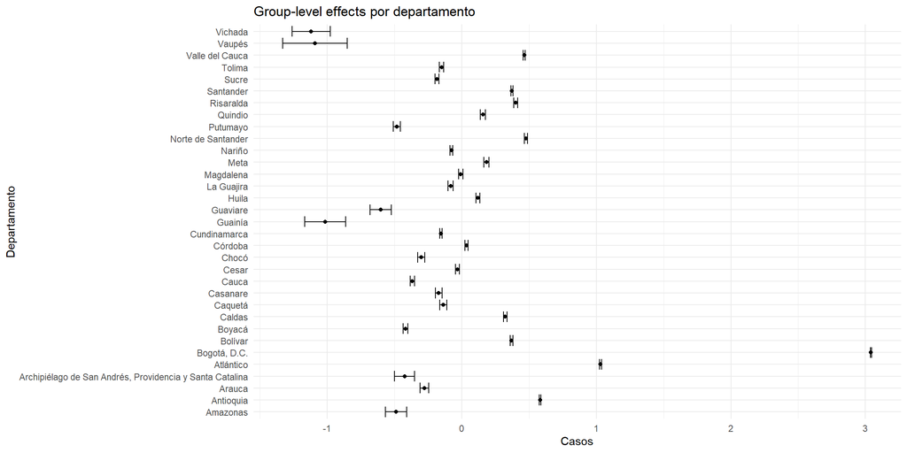

Figure 4: Evaluación del modelo ajustado

```r
tidy_re <- tidy(Neurodesarrollo_Fit2 , effects = "ran_vals", conf.int = TRUE)

tidy_Departamento <- tidy_re %>%
  filter(group == "Departamento")

ggplot(tidy_Departamento, aes(x = estimate, y = level)) +
  geom_point() +
  geom_errorbarh(aes(xmin = conf.low, xmax = conf.high)) +
  labs(
    title = "Group-level effects por departamento",
    x = "Casos",
    y = "Departamento"
  ) +
  theme_minimal()
```

Figure 4 nos muestra la desviación de diagnósticos por departamento.